# Final Project Advanced Modeling

## Comparing ML models

To better understand how our models make predictions, we examine variable importance and partial dependence plots. Variable importance highlights which predictors have the strongest influence on the model’s decisions, while partial dependence plots show thechanging effects of variabless.

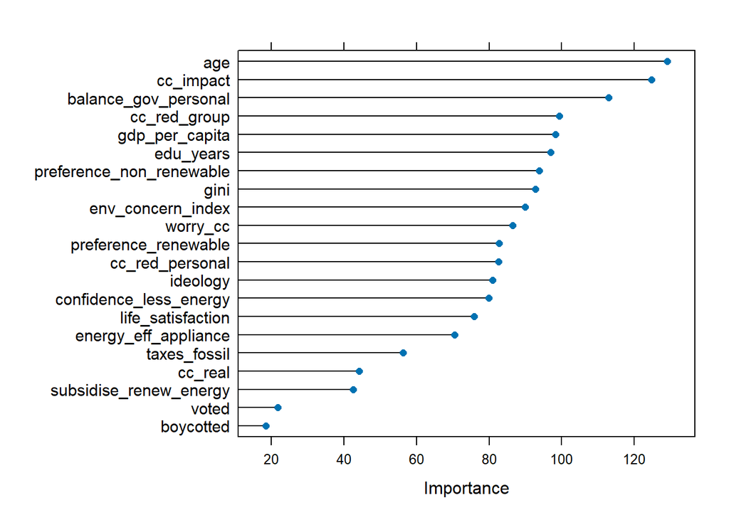

```r
rf_imp <- varImp(rfFit, scale = F)
plot(rf_imp, scales = list(y = list(cex = .95)))
```

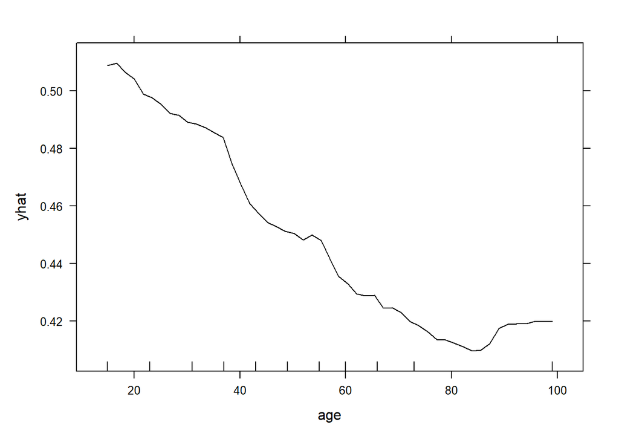

```r
partial(rfFit, pred.var = "age", which.class=2, plot = TRUE, prob=TRUE, rug = TRUE)
```

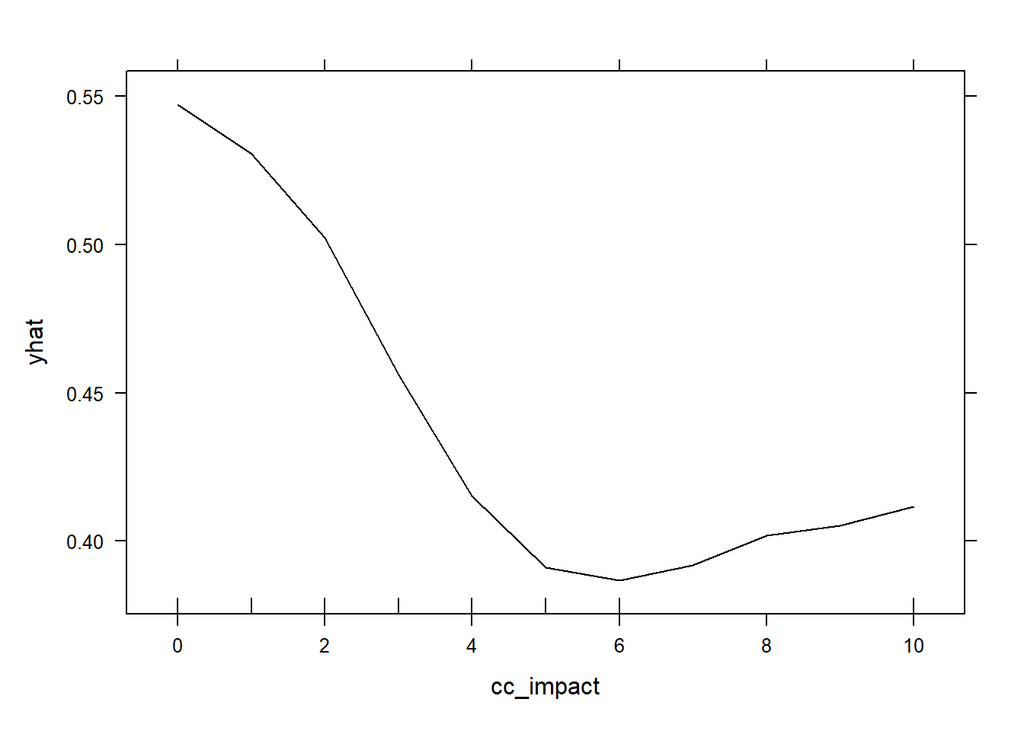

```r
partial(rfFit, pred.var = "cc_impact", which.class=2, plot = TRUE, prob=TRUE, rug = TRUE)
```

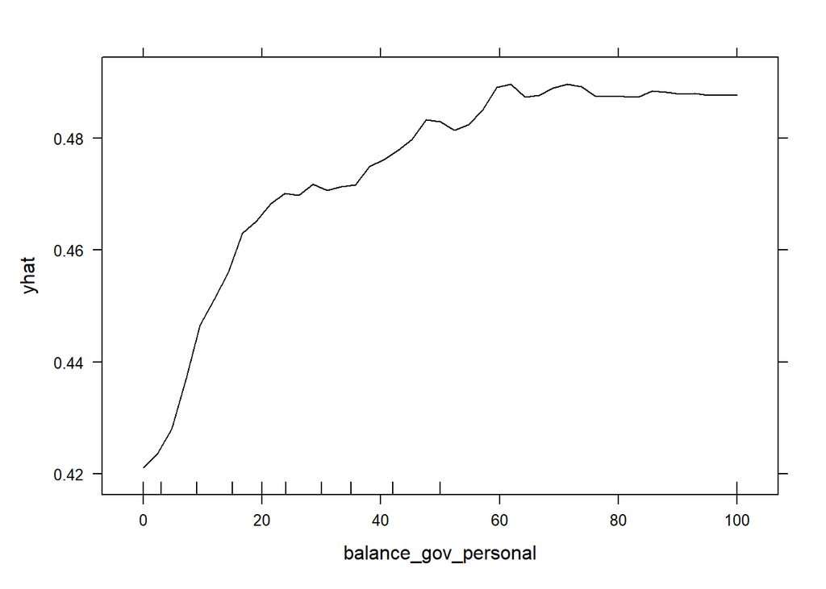

```r
partial(rfFit, pred.var = "balance_gov_personal", which.class=2, plot = TRUE, prob=TRUE, rug = TRUE)
```

The Random Forest variable importance plot highlights the key predictors driving the model’s classification of climate change belief. We can insert the top three variables, `age`, `cc_impact` and `balance_gov_personal` into the dependence plots.

The partial dependence plot for `age` shows a clear negative relationship: as age increases, the predicted probability of believing in climate change decreases, especially steeply from younger to middle ages before stabilising somewhat in older age groups. For `cc_impact`, which measures how good or bad respondents think the impact of climate change will be globally (0 = extremely bad, 10 = extremely good), higher perceived impact values correspond to a lower predicted probability of belief, indicating that those who view climate change impact more positively are less likely to believe in it. Lastly, the `balance_gov_personal` plot shows a positive relationship with belief probability: as respondents assign more responsibility to the government relative to themselves for addressing climate change, the likelihood of belief increases, leveling off at higher values.

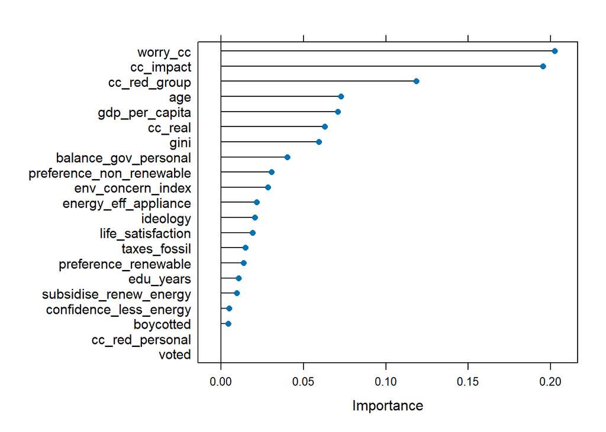

```r
gbm_imp <- varImp(gbmFit, scale = F)
plot(gbm_imp, scales = list(y = list(cex = .95)))
```

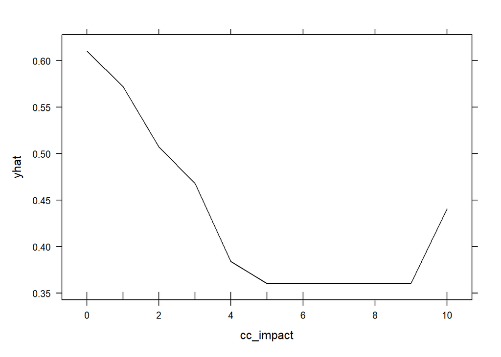

```r
partial(gbmFit, pred.var = "cc_impact", which.class=2, plot = TRUE, prob=TRUE, rug = TRUE)
```

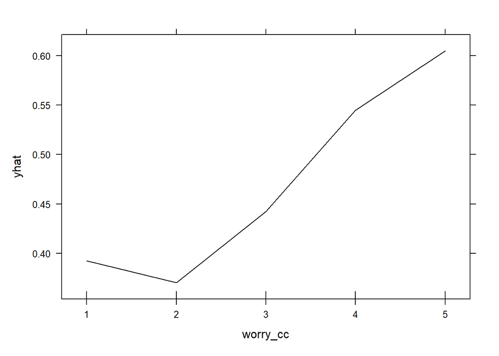

```r
partial(gbmFit, pred.var = "worry_cc", which.class=2, plot = TRUE, prob=TRUE, rug = TRUE)
```